# k nearest neighbors

By the end of this tutorial, you be able to:

- Use R to conduct k-nearest neighbors

## The Data

For this tutorial, we are using the `penguins` data set from the [`palmerpenguins` R package](https://allisonhorst.github.io/palmerpenguins/index.html) maintained by Dr. Allison Horst. This data contains measurements and other characteristics for 344 penguins observed near Palmer Station Antarctica. The data were originally collected by Dr. Kristen Gorman. Click [here](https://allisonhorst.github.io/palmerpenguins/reference/penguins.html) to view the codebook for this data set.

Let’s start by loading the palmerpenguins R package.

```r
library(palmerpenguins)
```

Next, we’ll take a quick look at the `penguins` data set to get a general idea of the variables and their types, the number of observations, and some of the values for each variable.

```r
glimpse(penguins)
```

```
## Rows: 344
## Columns: 8
## $ species           <fct> Adelie, Adelie, Adelie, Adelie, Adelie, Adelie, Ade…
## $ island            <fct> Torgersen, Torgersen, Torgersen, Torgersen, Torgers…
## $ bill_length_mm    <dbl> 39.1, 39.5, 40.3, NA, 36.7, 39.3, 38.9, 39.2, 34.1,…
## $ bill_depth_mm     <dbl> 18.7, 17.4, 18.0, NA, 19.3, 20.6, 17.8, 19.6, 18.1,…
## $ flipper_length_mm <int> 181, 186, 195, NA, 193, 190, 181, 195, 193, 190, 18…
## $ body_mass_g       <int> 3750, 3800, 3250, NA, 3450, 3650, 3625, 4675, 3475,…
## $ sex               <fct> male, female, female, NA, female, male, female, mal…
## $ year              <int> 2007, 2007, 2007, 2007, 2007, 2007, 2007, 2007, 200…
```

There are some observations with missing values for the measurements, so we will remove those for the purposes of this analysis:

```r
penguins <- penguins %>%
  drop_na()
```

## Exploratory data analysis

We will use k-nearest neighbors to classify the penguins into three groups based on their measurements (more about this later). Before performing the classification, let’s do a brief exploratory data analysis to take a look at the data.

We will use `body_mass_g`, `bill_length_mm`, `bill_depth_mm`, and `flipper_length_mm` to classify the penguins, so we’ll focus on these variables.

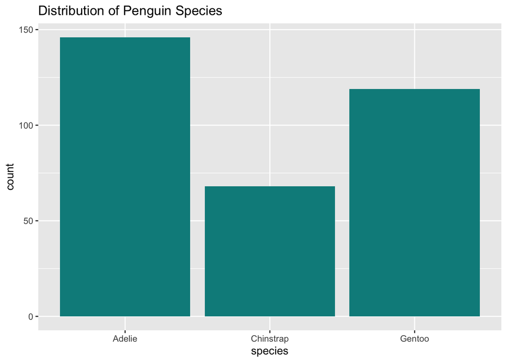

```r
ggplot(data = penguins, aes(x = species)) +
  geom_bar(fill = "cyan4") +
  labs(title = "Distribution of Penguin Species")
```

We can use the `ggpairs` function in the `GGally` package to quickly view the relationship between the measurements we’ll use for classification.

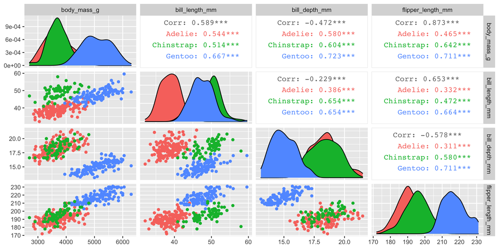

```r
library(GGally)
penguins %>%
  select(species, body_mass_g, bill_length_mm, bill_depth_mm, flipper_length_mm) %>%
  ggpairs(columns = c("body_mass_g", "bill_length_mm", "bill_depth_mm", "flipper_length_mm"),
          aes(color = species))
```

## k-nearest neighbors

Suppose we have the measurements for 3 new penguins but we don’t know their species. We can use k-nearest neighbors to predict the class for the new penguins by taking the plurality vote of its *k* nearest neighbors in terms of their class (species) memberships.

Here is the data for the three new penguins:

|  | Body Mass | Bill Length | Bill Depth | Flipper Length |
| --- | --- | --- | --- | --- |
| Penguin 1 | 3706 | 38.8 | 18.3 | 190 |
| Penguin 2 | 3733 | 46.3 | 17.5 | 191 |
| Penguin 3 | 3950 | 47.4 | 15 | 216 |

```r
new_penguins <- tibble(body_mass_g = c(3706, 3733, 3950),
                       bill_length_mm = c(38.8, 46.3, 47.4),
                       bill_depth_mm = c(18.3, 17.5, 15),
                       flipper_length_mm = c(190, 191, 216))
```

We will use the `knn()` function from the `class` package.

For the `knn` we need to create a vector of the species in our data.

```r
species <- penguins %>%
  select(species) %>%
  pull()
```

We will also create a new data frame that only contains the measurements we’re using for the k-nearest neighbors. By using the `ends_with` option in the `select` function, we can select `bill_length_mm`, `bill_depth_mm`, and `flipper_length_mm` without typing each variable name individually.

```r
penguins_knn <- penguins %>%
  select(body_mass_g, ends_with("_mm"))
```

### Choosing *k*

Now we’re ready to perform k-nearest neighbors. Since we know there are three species of penguins in the data set, we will set `k = 3` to specify there are three classes. Sometimes it is not as clear what $k$ should be, so you will have to use your judgment along with the context of the analysis question to choose a value of $k$. Here are a few considerations when using $k$:

- A larger value of $k$ reduces variance, but is computationally expensive and makes class boundaries harder to distinguish.
- A smaller value of $k$ results in sharp class boundaries, but may be too sensitive to the local data structure.
- For binary classification, it’s helpful to choose an odd value for $k$ to avoid ties. In general, avoid using even values for $k$.
- A commonly chosen simple approach is to use the square root of the sample size. For example, if the same size is 100, use $k = \sqrt{100} = 10$ as your starting point.

### Classify the new penguins

Now let’s use the `knn` function in R to classify the new penguins.

```r
library(class)

knn_species <- knn(train = penguins_knn, test = new_penguins, cl = species, k = 3, prob = FALSE)
```

The `knn` function has the following arguments:

- `train`: This is the data frame of training set cases, i.e. the data from the `penguins` data set in our example. The training data set should **only** include the variables that will be used to classify observations. In our example, these variables are `body_mass_g`, `bill_length_mm`, `bill_depth_mm`, and `flipper_length_mm`.
- `test`: This is the data frame of test set cases, i.e. the data frame containing the three new penguins in our example. Similar to the training data frame, the test data frame should only include the variables used for classification.
- `cl`: A vector of true class labels.
- `k`: Number of classes

Optional arguments are

- `prob`: If it’s true, the “votes” for the winning class are returned as the `prob` attribute. We’ll set it to `FALSE` for our example.
- `use.all`: This decides how R will handle ties. If it’s true, the all distances equal to the $k^{th}$ largest are used. Otherwise, a random selection of distances equal to the $k^{th}$ largest are used.

We assign the function output to the object `knn_species`. This is a vector of the predicted species for our three new penguins.

```r
knn_species
```

```
## [1] Adelie    Adelie    Chinstrap
## Levels: Adelie Chinstrap Gentoo
```

Using k-nearest neighbors,

- Penguin 1 is predicted to be in the Adelie species.
- Penguin 2 is predicted to be in the Adelie species.
- Penguin 3 is predicted to be in the Chinstrap species.

## Resources

- “K-Nearest Neighbors” in [Introduction to Statistical Learning](https://faculty.marshall.usc.edu/gareth-james/ISL/ISLR%20Seventh%20Printing.pdf) by Gareth James, Daniela Witten, Trevor Hastie, Robert Tibshirani, pg. 39 - 42.
- [K-Nearest Neighbors Algorithm with Examples in R (Simply Explained knn)](https://towardsdatascience.com/k-nearest-neighbors-algorithm-with-examples-in-r-simply-explained-knn-1f2c88da405c) by Kshitiz Sirohi